# TEST1

2024-04-26

DATA A1 :

Importer les bibliothèques nécéssaires :

```r
library(forecast)
library(astsa)
library(lmtest)
library(tseries)
library(stats)
```

Importer le DataSet

```r
df <- read.table('C:/Users/yassi/Downloads/MRTSSM451211USN.csv',sep=',')
```

```r
head(df,10)
```

```
##            V1              V2
## 1        DATE MRTSSM451211USN
## 2  1992-01-01             790
## 3  1992-02-01             539
## 4  1992-03-01             535
## 5  1992-04-01             523
## 6  1992-05-01             552
## 7  1992-06-01             589
## 8  1992-07-01             592
## 9  1992-08-01             894
## 10 1992-09-01             861
```

Les données comportent actuellement des colonnes V1 et V2, cependant, les véritables noms des colonnes sont présents dans la première ligne du jeu de données. Nous allons corriger cela en remplaçant les noms de colonnes par ceux de la première ligne.

```r
colnames(df) <- df[1,]
df <- df[-1,]
```

```r
df$DATE <- as.Date(df$DATE)
head(df,10)
```

```
##          DATE MRTSSM451211USN
## 2  1992-01-01             790
## 3  1992-02-01             539
## 4  1992-03-01             535
## 5  1992-04-01             523
## 6  1992-05-01             552
## 7  1992-06-01             589
## 8  1992-07-01             592
## 9  1992-08-01             894
## 10 1992-09-01             861
## 11 1992-10-01             645
```

Nous allons attribuer les valeurs de la colonne ‘DATE’ du dataframe ‘df’ aux noms de lignes du dataframe.  
Cela signifie que chaque ligne du dataframe sera maintenant identifiée par la valeur de la colonne ‘DATE’ correspondante.

```r
rownames(df) <- df$DATE
```

Vérification des valeurs manquantes :

```r
if (any(is.na(df))) {
  print("Il y a des valeurs manquantes dans le jeu de données.")
} else {
  print("Il n'y a pas de valeurs manquantes dans le jeu de données.")
}
```

```
## [1] "Il n'y a pas de valeurs manquantes dans le jeu de données."
```

Convertir les données :

```r
df <- ts(df$MRTSSM451211USN,start =1994,end = 2010,freq = 12)
df <- as.numeric(df)
```

```r
df
```

```
##   [1]  790  539  535  523  552  589  592  894  861  645  642 1165  998  568  602
##  [16]  583  612  618  607  983  903  669  692 1273 1053  635  634  610  684  724
##  [31]  678 1154 1022  732  772 1409 1308  718  695  688  785  808  782 1248 1102
##  [46]  746  850 1466 1373  757  743  750  853  838  786 1359 1040  899  908 1599
##  [61] 1558  825  813  806  894  875  830 1301 1158  923  994 1765 1463  921  882
##  [76]  854  919  939  881 1385 1246  953  990 1849 1514  990  976  933  976 1031
##  [91] 1023 1386 1240 1019 1088 1996 1505 1090 1031  975 1104 1122 1048 1594 1406
## [106] 1014 1098 1892 1585 1070 1062  934 1070 1077 1005 1820 1406 1015 1098 1956
## [121] 1971 1000 1008  966 1116 1045 1038 1797 1490  997 1059 1950 2056  991  925
## [136]  975 1107 1181 1128 2139 1572 1045 1036 2064 2146 1108 1073 1023 1113 1207
## [151] 1172 2120 1561 1069 1089 2200 2076 1086 1101  997 1120 1154 1214 2218 1554
## [166] 1064 1151 2257 2225 1101 1092  987 1176 1238 1135 2142 1554 1054 1142 2132
## [181] 2220 1039 1027  930 1134 1161 1220 2327 1578 1129 1227 2179 2300
```

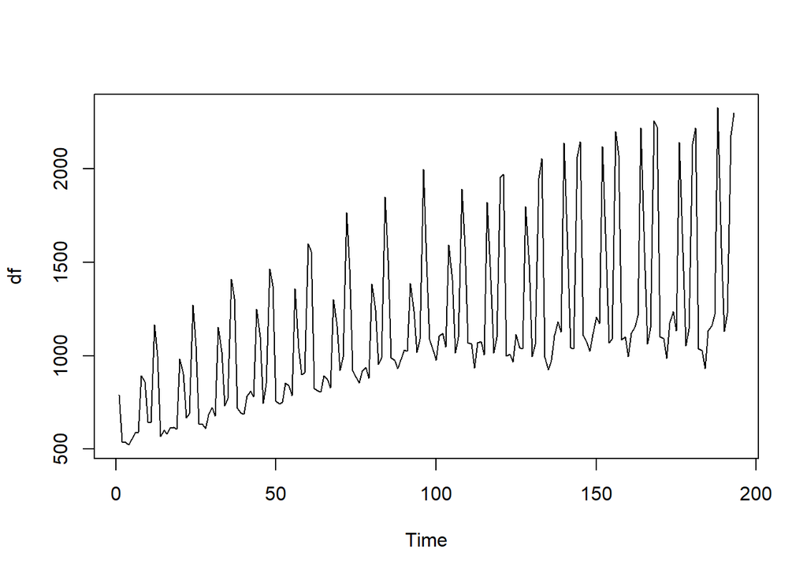

```r
ts.plot(df)
```

Visualiser les données :

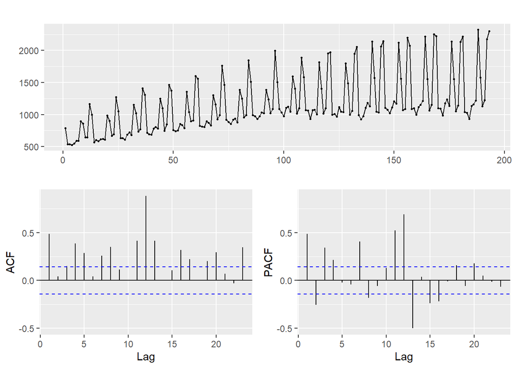

```r
data <- as.numeric(df)
ggtsdisplay(data)
```

On peut voir clairement que notre data présente une tendance positive au cours du temps d’après le 1er plot.  
Donc on doit différencier notre data.

```r
df_diff <- diff(log(data))
```

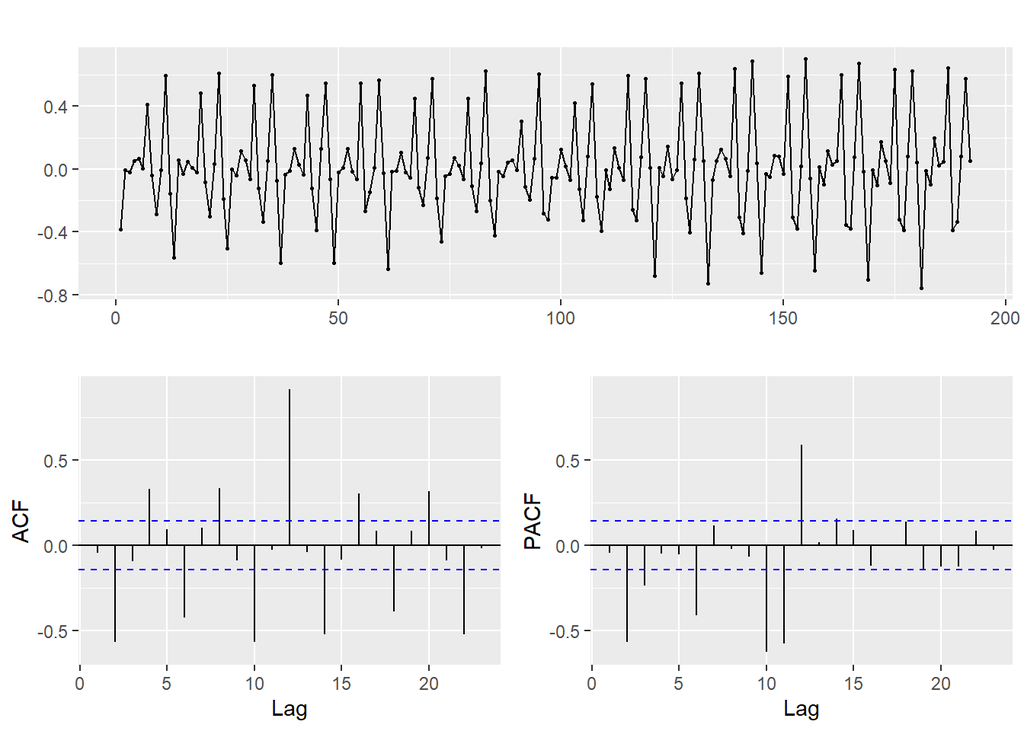

```r
ggtsdisplay(df_diff)
```

Maintenant, nous pouvons clairement voir que nos données présentent une saisonnalité.

Test de Stationnarité :

```r
adf.test(df_diff)
```

```
##
##  Augmented Dickey-Fuller Test
##
## data:  df_diff
## Dickey-Fuller = -11.572, Lag order = 5, p-value = 0.01
## alternative hypothesis: stationary
```

–> p_value = 0.01 < 0.05 , donc H1 accepté => Les données sont maintenant stationnaires.

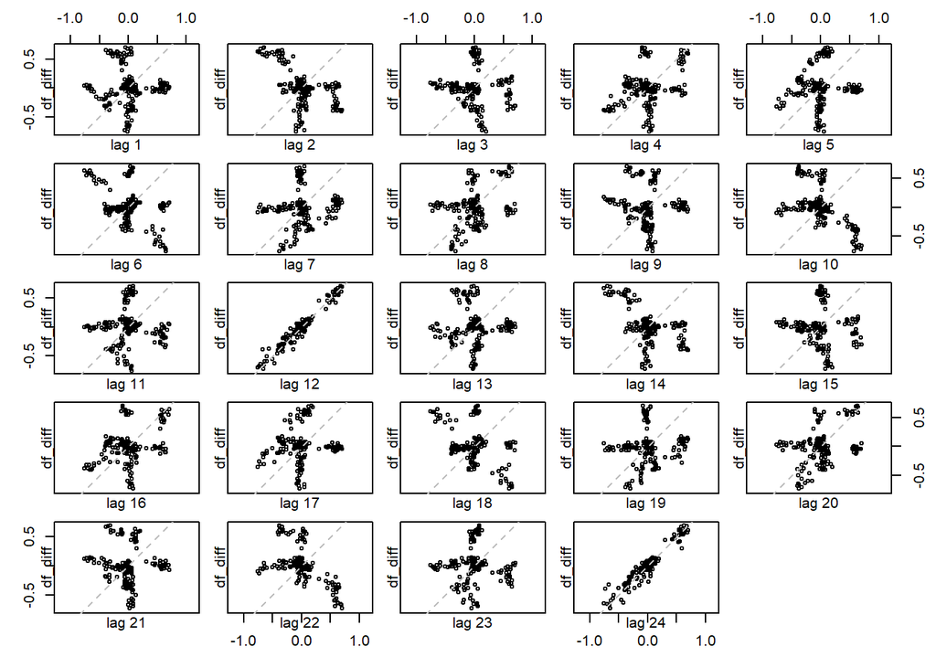

```r
lag.plot(df_diff,lag=24,do.lines=F)
```

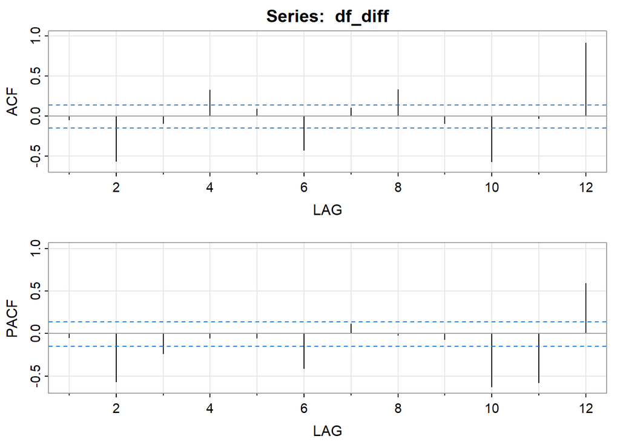

```
##       [,1]  [,2]  [,3]  [,4]  [,5]  [,6] [,7]  [,8]  [,9] [,10] [,11] [,12]
## ACF  -0.05 -0.57 -0.09  0.33  0.09 -0.42 0.10  0.33 -0.09 -0.57 -0.03  0.91
## PACF -0.05 -0.57 -0.24 -0.05 -0.05 -0.41 0.11 -0.02 -0.07 -0.63 -0.58  0.59
```

```r
acf2(df_diff,max.lag = 12)
```

D’apres ACF ,il y’a depassement de seuil donc on a des informations ainsi le bruit n’est pas blanc.

# Ajustement de la tendance

```r
t <- 1:length(df)
linear_model <- lm(df~t)
```

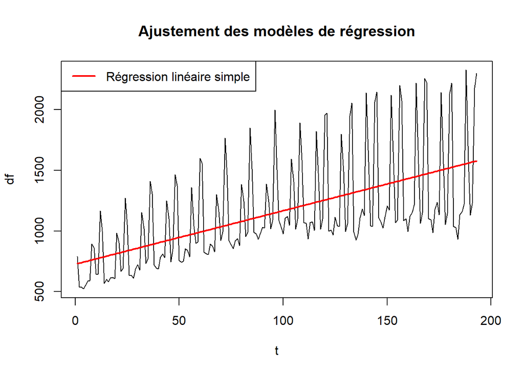

```r
plot(t, df,type='l', main="Ajustement des modèles de régression")
lines(t, linear_model$fitted.values, col="red", lwd=2)
legend("topleft", legend="Régression linéaire simple",
      col="red", lty=1, lwd=2)
```

```r
summary(linear_model)
```

```
##
## Call:
## lm(formula = df ~ t)
##
## Residuals:
##    Min     1Q Median     3Q    Max
## -608.0 -220.5 -136.1  194.5  846.0
##
## Coefficients:
##             Estimate Std. Error t value Pr(>|t|)
## (Intercept) 726.6540    51.3773  14.143   <2e-16 ***
## t             4.4095     0.4593   9.601   <2e-16 ***
## ---
## Signif. codes:  0 '***' 0.001 '**' 0.01 '*' 0.05 '.' 0.1 ' ' 1
##
## Residual standard error: 355.5 on 191 degrees of freedom
## Multiple R-squared:  0.3255, Adjusted R-squared:  0.322
## F-statistic: 92.17 on 1 and 191 DF,  p-value: < 2.2e-16
```

```r
degree_2 <- poly(t, 2)
degree_3 <- poly(t, 3)

degree_2_model <- lm(df ~ degree_2)
degree_3_model <- lm(df ~ degree_3)
```

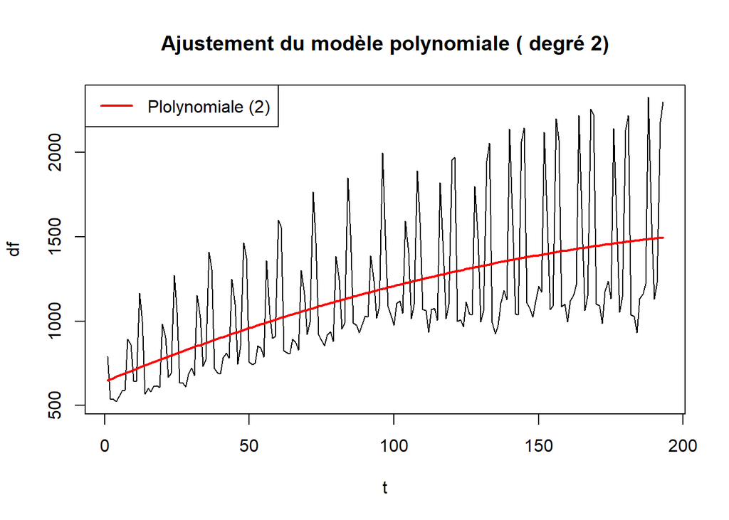

```r
plot(t, df,type='l', main="Ajustement du modèle polynomiale ( degré 2)")
lines(t, degree_2_model$fitted.values, col="red", lwd=2)
legend("topleft", legend="Plolynomiale (2)",
      col="red", lty=1, lwd=2)
```

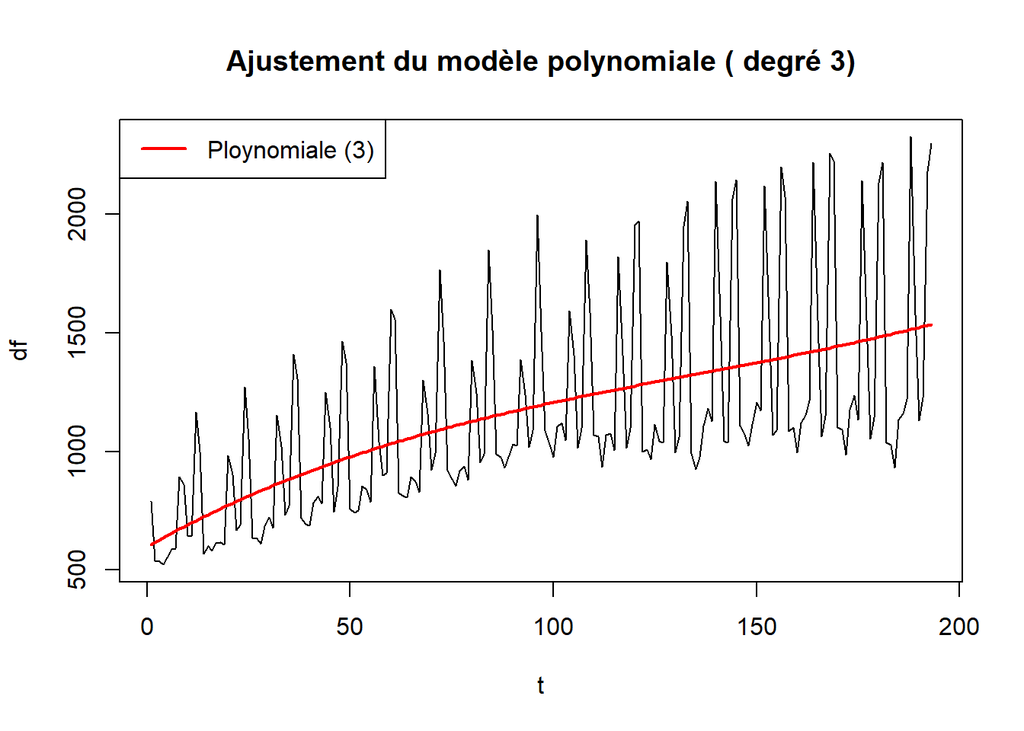

```r
plot(t, df,type='l', main="Ajustement du modèle polynomiale ( degré 3)")
lines(t, degree_3_model$fitted.values, col="red", lwd=2)
legend("topleft", legend="Ploynomiale (3)",
      col="red", lty=1, lwd=2)
```

```r
AIC(degree_2_model,degree_3_model,linear_model)
```

```
##                df      AIC
## degree_2_model  4 2818.734
## degree_3_model  5 2820.340
## linear_model    3 2818.872
```

```r
BIC(degree_2_model,degree_3_model,linear_model)
```

```
##                df      BIC
## degree_2_model  4 2831.784
## degree_3_model  5 2836.653
## linear_model    3 2828.660
```

# Modélisation de la tendance et de la composante saisonnière

Modèle mixte :

```r
MC=matrix(0, length(df), 6)
MS=matrix(0, length(df), 6)
for (i in 1:6)
  MC[,i]=cos(2 *pi *t * i/12)
for (i in 1:6)
  MS[,i]=sin(2 * pi * t * i/12)
mixed_model=lm(df~poly(t,2,raw=TRUE) + MC + MS)
summary(mixed_model)
```

```
##
## Call:
## lm(formula = df ~ poly(t, 2, raw = TRUE) + MC + MS)
##
## Residuals:
##     Min      1Q  Median      3Q     Max
## -374.00  -80.45   18.24   62.79  423.80
##
## Coefficients:
##                           Estimate Std. Error t value Pr(>|t|)
## (Intercept)              6.405e+02  2.724e+01  23.515  < 2e-16 ***
## poly(t, 2, raw = TRUE)1  7.289e+00  6.480e-01  11.249  < 2e-16 ***
## poly(t, 2, raw = TRUE)2 -1.567e-02  3.235e-03  -4.845 2.74e-06 ***
## MC1                      1.902e+02  1.268e+01  15.001  < 2e-16 ***
## MC2                      1.165e+02  1.272e+01   9.157  < 2e-16 ***
## MC3                      2.396e+02  1.278e+01  18.748  < 2e-16 ***
## MC4                      8.849e+01  1.281e+01   6.909 8.35e-11 ***
## MC5                     -1.877e+01  1.276e+01  -1.471  0.14301
## MC6                      2.611e+01  9.995e+00   2.613  0.00975 **
## MS1                     -1.130e+02  1.273e+01  -8.878 7.23e-16 ***
## MS2                      2.063e+02  1.268e+01  16.269  < 2e-16 ***
## MS3                      1.820e+02  1.275e+01  14.267  < 2e-16 ***
## MS4                     -1.053e+01  1.271e+01  -0.829  0.40821
## MS5                      1.047e+02  1.274e+01   8.222 4.04e-14 ***
## MS6                     -3.842e+14  3.613e+14  -1.064  0.28894
## ---
## Signif. codes:  0 '***' 0.001 '**' 0.01 '*' 0.05 '.' 0.1 ' ' 1
##
## Residual standard error: 124.7 on 178 degrees of freedom
## Multiple R-squared:  0.9227, Adjusted R-squared:  0.9166
## F-statistic: 151.8 on 14 and 178 DF,  p-value: < 2.2e-16
```

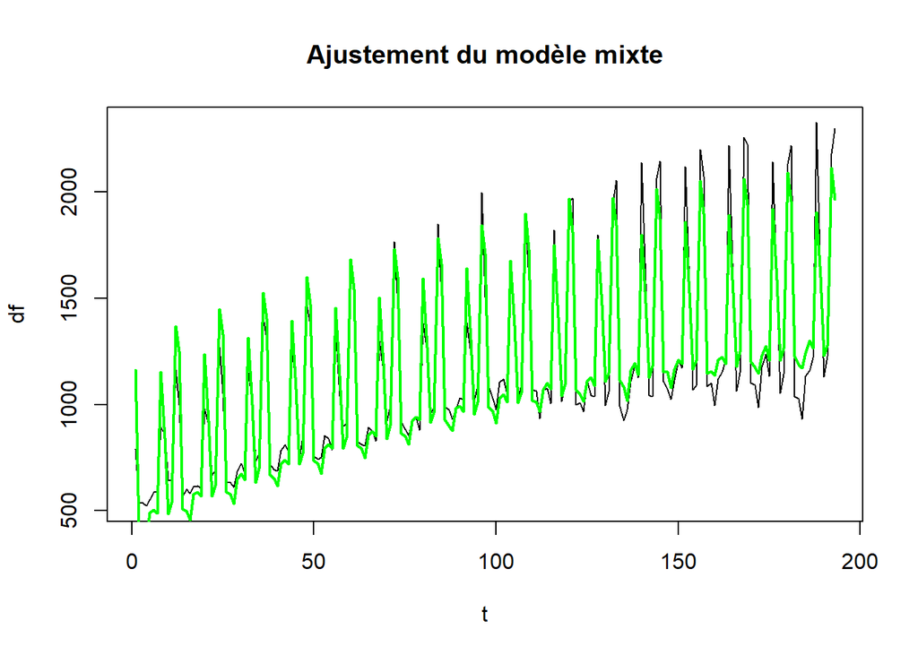

```r
plot(t,df,type='l', main="Ajustement du modèle mixte")
lines(t, mixed_model$fitted.values, col="green", lwd=2)
```

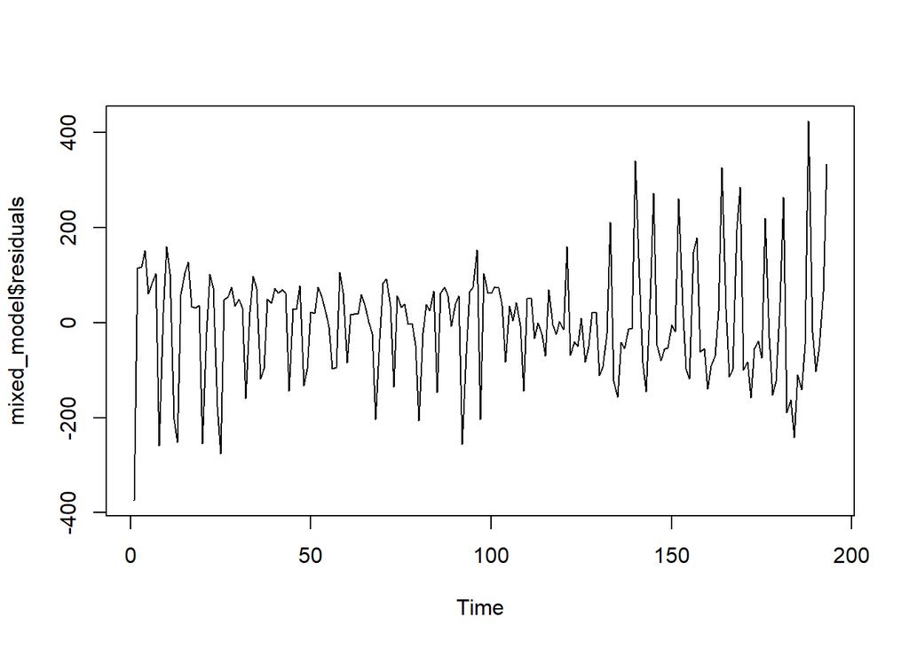

```r
ts.plot(mixed_model$residuals)
```

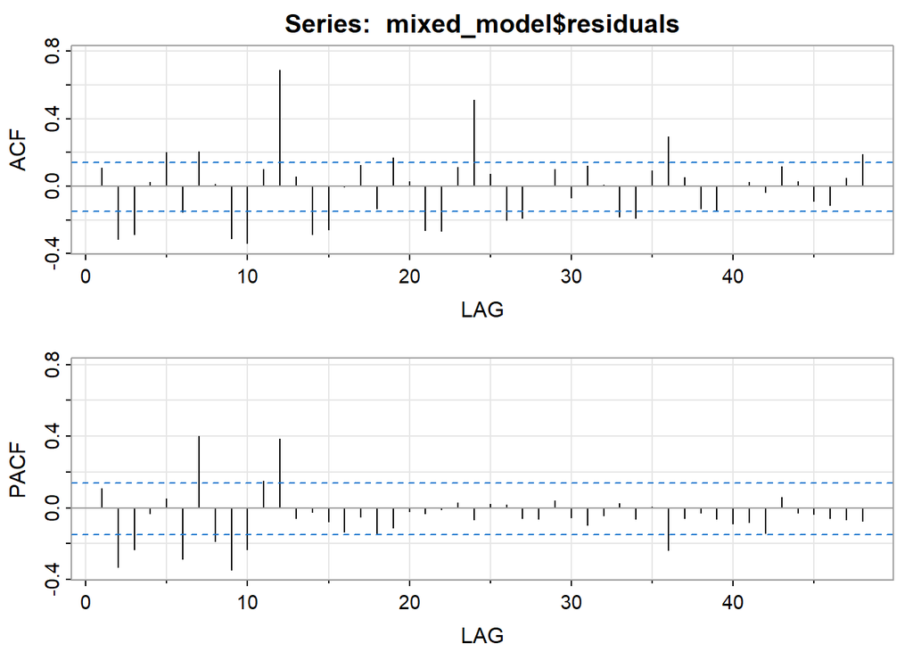

```
##      [,1]  [,2]  [,3]  [,4] [,5]  [,6] [,7]  [,8]  [,9] [,10] [,11] [,12] [,13]
## ACF  0.11 -0.32 -0.29  0.02 0.20 -0.15  0.2  0.01 -0.31 -0.34  0.10  0.69  0.06
## PACF 0.11 -0.33 -0.23 -0.03 0.05 -0.28  0.4 -0.19 -0.35 -0.23  0.15  0.38 -0.06
##      [,14] [,15] [,16] [,17] [,18] [,19] [,20] [,21] [,22] [,23] [,24] [,25]
## ACF  -0.28 -0.26  0.00  0.13 -0.13  0.17  0.03 -0.26 -0.27  0.11  0.51  0.07
## PACF -0.02 -0.08 -0.13 -0.05 -0.14 -0.11 -0.02 -0.03 -0.01  0.03 -0.07  0.02
##      [,26] [,27] [,28] [,29] [,30] [,31] [,32] [,33] [,34] [,35] [,36] [,37]
## ACF  -0.20 -0.19  0.00  0.10 -0.07  0.12  0.01 -0.18 -0.19  0.09  0.29  0.05
## PACF  0.02 -0.06 -0.06  0.04 -0.05 -0.10 -0.04  0.03 -0.06  0.01 -0.24 -0.06
##      [,38] [,39] [,40] [,41] [,42] [,43] [,44] [,45] [,46] [,47] [,48]
## ACF  -0.13 -0.14  0.00  0.03 -0.04  0.12  0.03 -0.09 -0.11  0.05  0.19
## PACF -0.03 -0.06 -0.09 -0.08 -0.14  0.06 -0.03 -0.03 -0.06 -0.07 -0.07
```

```r
acf2(mixed_model$residuals,max.lag = 48)
```

Dans le modèle mixte également, les résidus se situent près de zéro et affichent une faible variabilité par rapport aux valeurs prédites par le modèle. Cette observation peut être interprétée comme un signe que le modèle s’ajuste bien aux données. Cependant, l’analyse de la fonction ACF et de la PACF révèle une autocorrélation significative dans les résidus de ce modèle, suggérant ainsi que le modèle ne capture pas entièrement la variabilité des données et qu’il existe des informations non expliquées.

# Modèle ARMA pour la composante résiduelle

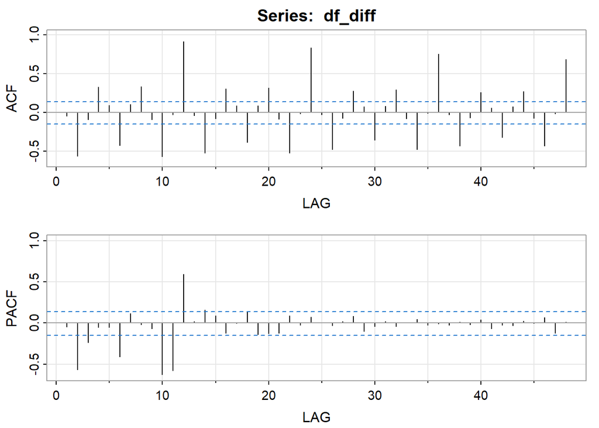

```
##       [,1]  [,2]  [,3]  [,4]  [,5]  [,6] [,7]  [,8]  [,9] [,10] [,11] [,12]
## ACF  -0.05 -0.57 -0.09  0.33  0.09 -0.42 0.10  0.33 -0.09 -0.57 -0.03  0.91
## PACF -0.05 -0.57 -0.24 -0.05 -0.05 -0.41 0.11 -0.02 -0.07 -0.63 -0.58  0.59
##      [,13] [,14] [,15] [,16] [,17] [,18] [,19] [,20] [,21] [,22] [,23] [,24]
## ACF  -0.04 -0.52 -0.08  0.30  0.09 -0.39  0.08  0.32 -0.09 -0.52 -0.02  0.83
## PACF  0.02  0.16  0.09 -0.12  0.00  0.14 -0.14 -0.13 -0.13  0.09 -0.03  0.07
##      [,25] [,26] [,27] [,28] [,29] [,30] [,31] [,32] [,33] [,34] [,35] [,36]
## ACF  -0.03 -0.48 -0.08  0.28  0.08 -0.36  0.08  0.29 -0.08 -0.48 -0.01  0.75
## PACF  0.00 -0.03  0.02  0.08 -0.10 -0.04  0.02 -0.04  0.01  0.05 -0.02 -0.01
##      [,37] [,38] [,39] [,40] [,41] [,42] [,43] [,44] [,45] [,46] [,47] [,48]
## ACF  -0.03 -0.43 -0.07  0.26  0.05 -0.32  0.08  0.27 -0.08 -0.43 -0.02  0.68
## PACF -0.03  0.01 -0.02  0.04 -0.07 -0.03 -0.03  0.02  0.00  0.07 -0.12  0.01
```

```r
acf2(df_diff,max.lag=48)
```

-> Ce qui suggère un model ARIMA(2,1,1)

```r
auto.arima(df,seasonal = TRUE)
```

```
## Series: df
## ARIMA(2,1,1)
##
## Coefficients:
##          ar1      ar2      ma1
##       0.3832  -0.4812  -0.9149
## s.e.  0.0651   0.0650   0.0231
##
## sigma^2 = 99960:  log likelihood = -1377.38
## AIC=2762.77   AICc=2762.98   BIC=2775.8
```

-> Cela vérifie notre choix du modèle ARIMA(2,1,1)

```
## <><><><><><><><><><><><><><>
##
## Coefficients:
##          Estimate     SE  t.value p.value
## ar1        0.3844 0.0638   6.0292       0
## ar2       -0.4801 0.0639  -7.5090       0
## ma1       -1.0000 0.0242 -41.3362       0
## constant   4.3417 0.3578  12.1340       0
##
## sigma^2 estimated as 90172.85 on 188 degrees of freedom
##
## AIC = 14.33086  AICc = 14.33197  BIC = 14.41569
##
```

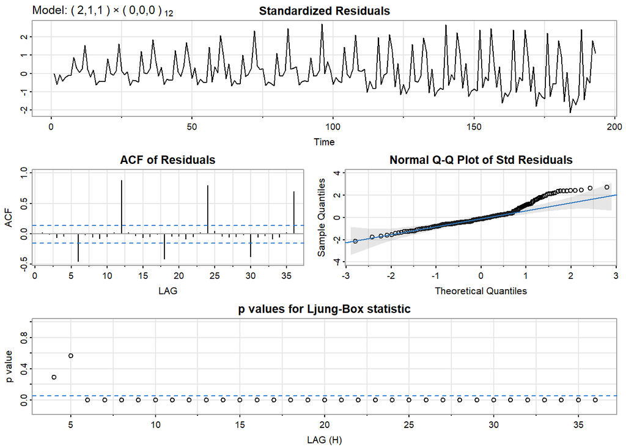

```r
sarima(df,p=2,d=1,q=1,P=0,D=0,Q=0,S=12)
```

–> Différenciation saisonière.

```
## <><><><><><><><><><><><><><>
##
## Coefficients:
##     Estimate     SE  t.value p.value
## ar1   0.1137 0.0776   1.4649  0.1447
## ar2   0.0383 0.0774   0.4955  0.6209
## ma1  -0.9641 0.0202 -47.6771  0.0000
##
## sigma^2 estimated as 5235.806 on 177 degrees of freedom
##
## AIC = 11.45868  AICc = 11.45944  BIC = 11.52964
##
```

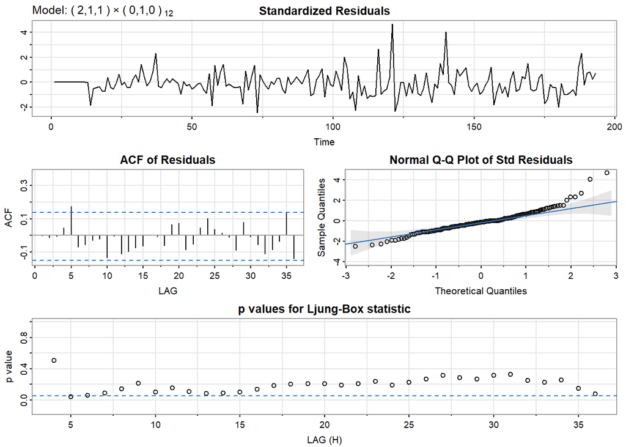

```r
sarima(df,p=2,d=1,q=1,P=0,D=1,Q=0,S=12)
```

–> Ce modèle explique bien les données.

```r
modèle_final <- arima(df,order=c(2,1,1),seasonal = list(order=c(0,1,0),period= 12))
```

Analyse des résidus du modèle :

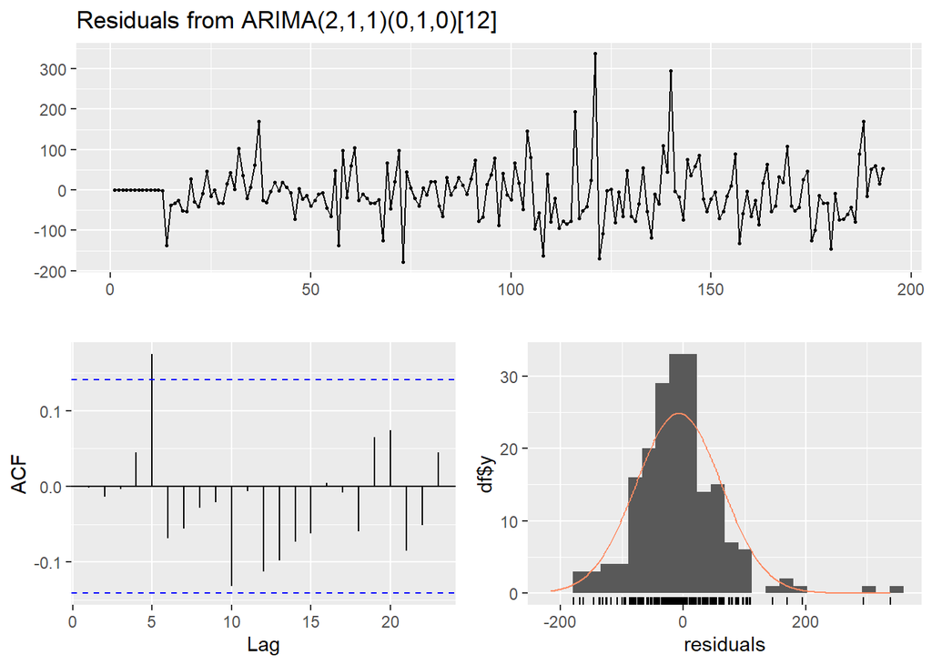

```
##
##  Ljung-Box test
##
## data:  Residuals from ARIMA(2,1,1)(0,1,0)[12]
## Q* = 11.953, df = 7, p-value = 0.1021
##
## Model df: 3.   Total lags used: 10
```

```r
checkresiduals(modèle_final)
```

```r
Box.test(modèle_final$residuals)
```

```
##
##  Box-Pierce test
##
## data:  modèle_final$residuals
## X-squared = 0.00053849, df = 1, p-value = 0.9815
```

–> p_value = 0.98 > 0.05  
Les résidus comportent comme un bruit blanc .

**Forecasting**

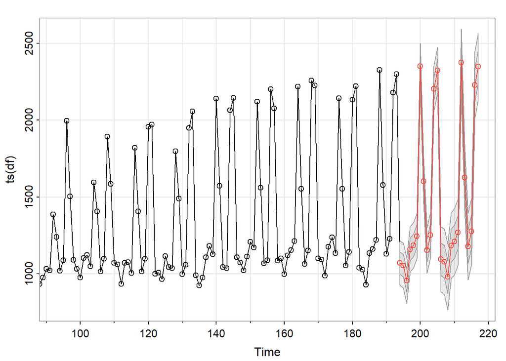

```
## $pred
## Time Series:
## Start = 194
## End = 217
## Frequency = 1
##  [1] 1070.6096 1054.3717  955.0345 1158.6062 1185.4679 1244.4357 2351.4268
##  [8] 1602.4245 1153.4239 1251.4238 2203.4237 2324.4237 1095.0333 1078.7954
## [15]  979.4582 1183.0299 1209.8916 1268.8594 2375.8505 1626.8482 1177.8476
## [22] 1275.8474 2227.8474 2348.8474
##
## $se
## Time Series:
## Start = 194
## End = 217
## Frequency = 1
##  [1]  72.35887  73.16420  73.46147  73.55776  73.63076  73.69656  73.76075
##  [8]  73.82444  73.88797  73.95142  74.01480  74.07813 105.71630 106.62463
## [15] 107.06173 107.27905 107.46624 107.64356 107.81847 107.99249 108.16609
## [22] 108.33937 108.51236 108.68507
```

```r
sarima.for(ts(df),n.ahead = 24,p=2,d=1,q=1,P=0,D=1,Q=0,S=12)
```